# South Africa Covid19 Data Analysis

# 1.Introduction

www.corona-stats.co.za launched a free API for historical South African COVID-19 data in April 2020. Data can be accessed using the link:“http://corona-stats.mobi/api/. This project entails accessing South African COVID-19 data from the API, compiling accessed data into useable datasets,Exploratory data analysis,data cleaning and representing the data in useable format i.e. data visualization utilizing Tableau.

The chunks of code below were used to access and compile data from the API. When report was knitted from RMarkdown the API key had expired. The data used inthe analysis was accessed and compiled before they key expired.

# 2.Data access

To extract data from the API R programming language packages:httr and Jsonlite were used.

```r
knitr::opts_chunk$set(error = TRUE)
```

```r
library(httr)
library(jsonlite)
library(dplyr)
base_url = "http://corona-stats.mobi/api/"
info_url = "json.2.0.php?key=J7t2b0NhyD8PSqT9ZMEY"
full_url = base::paste0(base_url,info_url)

api_call = httr::GET(full_url)
```

To check whether the request was successful the status code has to be 200. If it is around 400 it means the request was unsuccessful.

```r
api_call$status_code
```

```
## [1] 200
```

Converting the response to usable format

```r
api_char = base::rawToChar(api_call$content)

str(api_char)
```

```
##  chr "{\n    \"status\": [\n        402,\n        \"Expired API key. Please request a new key.\"\n    ],\n    \"times"| __truncated__
```

```r
api_Json = jsonlite::fromJSON(api_char,flatten = T)

api_Json
```

```
## $status
## [1] "402"
## [2] "Expired API key. Please request a new key."
##
## $timestamp
## [1] "15 November 2022, 14:53:17 SAST"
```

```r
str(api_Json)
```

```
## List of 2
##  $ status   : chr [1:2] "402" "Expired API key. Please request a new key."
##  $ timestamp: chr "15 November 2022, 14:53:17 SAST"
```

```r
Covid19_RSA = api_Json$RSA
```

The Covid19 data is in the RSA list.RSA contains 22 lists of South Africa Covid19 data.

# 3.Compiling accessed data to useable datasets

## a.National Data

```r
Dates1 = Covid19_RSA$Dates
View(Dates1)
```

```
## Error in View(Dates1): invalid 'x' argument
```

```r
SA_data = Covid19_RSA$National
Cases = SA_data$Cases
Recoveries = SA_data$Recoveries
Deaths = SA_data$Deaths
Tests = SA_data$Tests
Vaccinations = SA_data$Vaccinations
Daily_Cases = SA_data$`Daily Cases`
Daily_Deaths = SA_data$`Daily Deaths`
Daily_Vaccinations = SA_data$`Daily Vaccinations`
Cases_14day_average = SA_data$`Daily Cases 14 day average`
Deaths_14day_average = SA_data$`Daily Deaths 14 day average`
Vaccinations_14day_average = SA_data$`Vaccinations 14 day average`

mySA_Covid19data = data.frame(Date=Dates1,Total_Cases=Cases,Total_Recoveries=Recoveries,
                              Total_Deaths=Deaths,Total_Tests=Tests,Total_Vaccinations=Vaccinations,
                              Daily_Cases,Daily_Deaths,Daily_Vaccinations)

View(mySA_Covid19data)
```

```
## Error in View(mySA_Covid19data): invalid 'x' argument
```

```r
library(writexl)

write_xlsx(mySA_Covid19data,"SaCovid19.xlsx")
```

```
## Error: Error in libxlsxwriter: 'Error creating output xlsx file. Usually a permissions error.'
```

## Western Cape Data

```r
WC_data = Covid19_RSA$WC
Total_Cases = WC_data$Cases
Total_Recoveries = WC_data$Recoveries
Total_Deaths = WC_data$Deaths

Daily_Cases = WC_data$`Daily Cases`
Daily_Deaths = WC_data$`Daily Deaths`

Cases_14day_average = WC_data$`Daily Cases 14 day average`
Deaths_14day_average = WC_data$`Daily Deaths 14 day average`


WC_Covid19data = data.frame(Date=Dates1,Total_Cases,Total_Recoveries,Total_Deaths,Daily_Cases,Daily_Deaths,Cases_14day_average,Deaths_14day_average)

#write_xlsx(WC_Covid19data,"WesternCapeCovid19.xlsx")
library(readxl)
#WC = read_excel("~/GitHub/South-Africa-COVID19/WesternCapeCovid19.xlsx")
#WC_data = mutate(WC,Province = "Western Cape")
```

## Gauteng Data

```r
Gauteng_data = Covid19_RSA$GP
Total_Cases = Gauteng_data$Cases
Total_Recoveries = Gauteng_data$Recoveries
Total_Deaths = Gauteng_data$Deaths

Daily_Cases = Gauteng_data$`Daily Cases`
Daily_Deaths = Gauteng_data$`Daily Deaths`

Cases_14day_average = Gauteng_data$`Daily Cases 14 day average`
Deaths_14day_average = Gauteng_data$`Daily Deaths 14 day average`


Gauteng_Covid19data = data.frame(Date=Dates1,Total_Cases,Total_Recoveries,Total_Deaths,Daily_Cases,Daily_Deaths,Cases_14day_average,Deaths_14day_average)

#write_xlsx(Gauteng_Covid19data,"GautengCovid19.xlsx")

#Gauteng = read_excel("~/GitHub/South-Africa-COVID19/GautengCovid19.xlsx")
#Gauteng_data = mutate(Gauteng,Province = "Gauteng")
```

## KZN Data

```r
KZN_data = Covid19_RSA$KZN
Total_Cases = KZN_data$Cases
Total_Recoveries = KZN_data$Recoveries
Total_Deaths = KZN_data$Deaths

Daily_Cases = KZN_data$`Daily Cases`
Daily_Deaths = KZN_data$`Daily Deaths`

Cases_14day_average = KZN_data$`Daily Cases 14 day average`
Deaths_14day_average = KZN_data$`Daily Deaths 14 day average`


KZN_Covid19data = data.frame(Date=Dates1,Total_Cases,Total_Recoveries,Total_Deaths,Daily_Cases,Daily_Deaths,Cases_14day_average,Deaths_14day_average)

#write_xlsx(KZN_Covid19data,"KZNCovid19.xlsx")

#KZN = read_excel("~/GitHub/South-Africa-COVID19/KZNCovid19.xlsx")
#KZN_data = mutate(KZN,Province = "KwaZulu-Natal")
```

## Eastern Cape Data

```r
EC_data = Covid19_RSA$EC
Total_Cases = EC_data$Cases
Total_Recoveries = EC_data$Recoveries
Total_Deaths = EC_data$Deaths

Daily_Cases = EC_data$`Daily Cases`
Daily_Deaths = EC_data$`Daily Deaths`

Cases_14day_average = EC_data$`Daily Cases 14 day average`
Deaths_14day_average = EC_data$`Daily Deaths 14 day average`


EC_Covid19data = data.frame(Date=Dates1,Total_Cases,Total_Recoveries,Total_Deaths,Daily_Cases,Daily_Deaths,Cases_14day_average,Deaths_14day_average)

#write_xlsx(EC_Covid19data,"ECCovid19.xlsx")

#EC = read_excel("~/GitHub/South-Africa-COVID19/ECCovid19.xlsx")
#EC_data = mutate(EC,Province = "Eastern Cape")
```

## Free State Data

```r
FS_data = Covid19_RSA$FS
Total_Cases = FS_data$Cases
Total_Recoveries = FS_data$Recoveries
Total_Deaths = FS_data$Deaths

Daily_Cases = FS_data$`Daily Cases`
Daily_Deaths = FS_data$`Daily Deaths`

Cases_14day_average = FS_data$`Daily Cases 14 day average`
Deaths_14day_average = FS_data$`Daily Deaths 14 day average`


FS_Covid19data = data.frame(Date=Dates1,Total_Cases,Total_Recoveries,Total_Deaths,Daily_Cases,Daily_Deaths,Cases_14day_average,Deaths_14day_average)

#write_xlsx(FS_Covid19data,"FSCovid19.xlsx")

#FS = read_excel("~/GitHub/South-Africa-COVID19/FSCovid19.xlsx")
#FS_data = mutate(FS,Province = "Free State")
```

## Mpumalanga Data

```r
MP_data = Covid19_RSA$MP
Total_Cases = MP_data$Cases
Total_Recoveries = MP_data$Recoveries
Total_Deaths = MP_data$Deaths

Daily_Cases = MP_data$`Daily Cases`
Daily_Deaths = MP_data$`Daily Deaths`

Cases_14day_average = MP_data$`Daily Cases 14 day average`
Deaths_14day_average = MP_data$`Daily Deaths 14 day average`


MP_Covid19data = data.frame(Date=Dates1,Total_Cases,Total_Recoveries,Total_Deaths,Daily_Cases,Daily_Deaths,Cases_14day_average,Deaths_14day_average)

#write_xlsx(MP_Covid19data,"MPCovid19.xlsx")

#MP = read_excel("~/GitHub/South-Africa-COVID19/MPCovid19.xlsx")
#MP_data = mutate(MP,Province = "Mpumalanga")
```

## Limpopo Data

```r
LP_data = Covid19_RSA$LP
Total_Cases = LP_data$Cases
Total_Recoveries = LP_data$Recoveries
Total_Deaths = LP_data$Deaths

Daily_Cases = LP_data$`Daily Cases`
Daily_Deaths = LP_data$`Daily Deaths`

Cases_14day_average = LP_data$`Daily Cases 14 day average`
Deaths_14day_average = LP_data$`Daily Deaths 14 day average`


LP_Covid19data = data.frame(Date=Dates1,Total_Cases,Total_Recoveries,Total_Deaths,Daily_Cases,Daily_Deaths,Cases_14day_average,Deaths_14day_average)

#write_xlsx(LP_Covid19data,"LPCovid19.xlsx")

#LP = read_excel("~/GitHub/South-Africa-COVID19/LPCovid19.xlsx")
#LP_data = mutate(LP, Province = "Limpopo")
```

## North West Data

```r
NW_data = Covid19_RSA$NW
Total_Cases = NW_data$Cases
Total_Recoveries = NW_data$Recoveries
Total_Deaths = NW_data$Deaths

Daily_Cases = NW_data$`Daily Cases`
Daily_Deaths = NW_data$`Daily Deaths`

Cases_14day_average = NW_data$`Daily Cases 14 day average`
Deaths_14day_average = NW_data$`Daily Deaths 14 day average`


NW_Covid19data = data.frame(Date=Dates1,Total_Cases,Total_Recoveries,Total_Deaths,Daily_Cases,Daily_Deaths,Cases_14day_average,Deaths_14day_average)

#write_xlsx(NW_Covid19data,"NWCovid19.xlsx")
#NW = read_excel("~/GitHub/South-Africa-COVID19/NWCovid19.xlsx")
#NW_data = mutate(NW,Province = "North West")
```

## Northern Cape Data

```r
NC_data = Covid19_RSA$NC
Total_Cases = NC_data$Cases
Total_Recoveries = NC_data$Recoveries
Total_Deaths = NC_data$Deaths

Daily_Cases = NC_data$`Daily Cases`
Daily_Deaths = NC_data$`Daily Deaths`

Cases_14day_average = NC_data$`Daily Cases 14 day average`
Deaths_14day_average = NC_data$`Daily Deaths 14 day average`


NC_Covid19data = data.frame(Date=Dates1,Total_Cases,Total_Recoveries,Total_Deaths,Daily_Cases,Daily_Deaths,Cases_14day_average,Deaths_14day_average)

#write_xlsx(NC_Covid19data,"NCCovid19.xlsx")

#NC = read_excel("~/GitHub/South-Africa-COVID19/NCCovid19.xlsx")
#NC_data = mutate(NC,Province = "Northern Cape")
```

All the provincial dataframes were combined into 1 dataset, Sa_ProvincialCOVID19.

# Exploratory Data Analysis

```r
Sa_ProvincialCOVID19 = rbind(WC_data,KZN_data,Gauteng_data,EC_data,FS_data,MP_data,LP_data,NW_data,NC_data)

Sa_ProvincialCOVID19 = read_excel("~\\GitHub\\South-Africa-COVID19\\docs\\Sa_ProvincialCovid19.xlsx")
mydata = Sa_ProvincialCOVID19
```

## A. Checking the total number of rows and columns

```r
nrow(mydata)
```

```
## [1] 7920
```

```r
ncol(mydata)
```

```
## [1] 9
```

## B. Basic data profiling

```r
library(funModeling)
df_status(mydata)
```

```
##               variable q_zeros p_zeros q_na p_na q_inf p_inf           type
## 1                 Date       0    0.00    0    0     0     0 POSIXct/POSIXt
## 2             Province       0    0.00    0    0     0     0      character
## 3          Total_Cases     130    1.64    0    0     0     0      character
## 4     Total_Recoveries     441    5.57    0    0     0     0      character
## 5         Total_Deaths     539    6.81    0    0     0     0      character
## 6          Daily_Cases     267    3.37    0    0     0     0      character
## 7         Daily_Deaths    3558   44.92    0    0     0     0      character
## 8  Cases_14day_average     215    2.71    0    0     0     0      character
## 9 Deaths_14day_average    1279   16.15    0    0     0     0      character
##   unique
## 1    880
## 2      9
## 3   7373
## 4   5621
## 5   3888
## 6   1748
## 7    209
## 8   1736
## 9    155
```

Columns q_zeros and p_zeros show the number of zeros and percentage of zeros per column respectively. Columns q_na and p_na show the number of na values and percentage of na values respectively.Column type shows the data types for all the columns. Some numerical values are read as characters above and also the date format needs to be changed.

```r
mydata$Date = as.Date(mydata$Date)
mydata$Daily_Deaths = as.numeric(mydata$Daily_Deaths)
mydata$Total_Cases = as.numeric(mydata$Total_Cases)
mydata$Total_Recoveries = as.numeric(mydata$Total_Recoveries)
mydata$Total_Deaths = as.numeric(mydata$Total_Deaths)
mydata$Daily_Cases = as.numeric(mydata$Daily_Cases)
mydata$Cases_14day_average = as.numeric(mydata$Cases_14day_average)
mydata$Deaths_14day_average = as.numeric(mydata$Deaths_14day_average)

df_status(mydata)
```

```
##               variable q_zeros p_zeros q_na p_na q_inf p_inf      type unique
## 1                 Date       0    0.00    0    0     0     0      Date    880
## 2             Province       0    0.00    0    0     0     0 character      9
## 3          Total_Cases     130    1.64    0    0     0     0   numeric   7373
## 4     Total_Recoveries     441    5.57    0    0     0     0   numeric   5621
## 5         Total_Deaths     539    6.81    0    0     0     0   numeric   3888
## 6          Daily_Cases     267    3.37    0    0     0     0   numeric   1748
## 7         Daily_Deaths    3558   44.92    0    0     0     0   numeric    209
## 8  Cases_14day_average     215    2.71    0    0     0     0   numeric   1736
## 9 Deaths_14day_average    1279   16.15    0    0     0     0   numeric    155
```

All the column data types have been corrected. To find the statistical properties of the data:

```r
summary(mydata)
```

```
##       Date              Province          Total_Cases      Total_Recoveries
##  Min.   :2020-03-02   Length:7920        Min.   :      0   Min.   :      0
##  1st Qu.:2020-10-07   Class :character   1st Qu.:  36889   1st Qu.:  31763
##  Median :2021-05-15   Mode  :character   Median : 123398   Median : 115233
##  Mean   :2021-05-15                      Mean   : 216327   Mean   : 203103
##  3rd Qu.:2021-12-21                      3rd Qu.: 277520   3rd Qu.: 254154
##  Max.   :2022-07-29                      Max.   :1325623   Max.   :1303847
##   Total_Deaths      Daily_Cases       Daily_Deaths     Cases_14day_average
##  Min.   :    0.0   Min.   :-6624.0   Min.   :-186.00   Min.   :  -31.0
##  1st Qu.:  659.5   1st Qu.:   45.0   1st Qu.:   0.00   1st Qu.:   55.0
##  Median : 3673.0   Median :  157.0   Median :   2.00   Median :  177.0
##  Mean   : 6086.5   Mean   :  505.6   Mean   :  12.88   Mean   :  505.4
##  3rd Qu.:10509.2   3rd Qu.:  471.0   3rd Qu.:  12.00   3rd Qu.:  477.0
##  Max.   :22308.0   Max.   :17716.0   Max.   : 515.00   Max.   :10940.0
##  Deaths_14day_average
##  Min.   : -4.00
##  1st Qu.:  1.00
##  Median :  4.00
##  Mean   : 12.89
##  3rd Qu.: 14.00
##  Max.   :164.00
```

There appears to be an error in the Daily_Deaths,Daily_Cases, Deaths_14day_average and Cases_14day_average columns. The minimum values are negative and that needs to be rectified. All the negative numbers will be replaced by the variable’s absolute value.

```r
mydata_sorted = mydata[order(mydata$Date),]
mydata_sorted$Daily_Cases = abs(mydata_sorted$Daily_Cases)
mydata_sorted$Daily_Deaths = abs(mydata_sorted$Daily_Deaths)
mydata_sorted$Deaths_14day_average = abs(mydata_sorted$Deaths_14day_average)
mydata_sorted$Cases_14day_average = abs(mydata_sorted$Cases_14day_average)
summary(mydata_sorted)
```

```
##       Date              Province          Total_Cases      Total_Recoveries
##  Min.   :2020-03-02   Length:7920        Min.   :      0   Min.   :      0
##  1st Qu.:2020-10-07   Class :character   1st Qu.:  36889   1st Qu.:  31763
##  Median :2021-05-15   Mode  :character   Median : 123398   Median : 115233
##  Mean   :2021-05-15                      Mean   : 216327   Mean   : 203103
##  3rd Qu.:2021-12-21                      3rd Qu.: 277520   3rd Qu.: 254154
##  Max.   :2022-07-29                      Max.   :1325623   Max.   :1303847
##   Total_Deaths      Daily_Cases       Daily_Deaths    Cases_14day_average
##  Min.   :    0.0   Min.   :    0.0   Min.   :  0.00   Min.   :    0.0
##  1st Qu.:  659.5   1st Qu.:   45.0   1st Qu.:  0.00   1st Qu.:   55.0
##  Median : 3673.0   Median :  158.0   Median :  2.00   Median :  177.0
##  Mean   : 6086.5   Mean   :  508.0   Mean   : 12.98   Mean   :  505.4
##  3rd Qu.:10509.2   3rd Qu.:  471.2   3rd Qu.: 12.00   3rd Qu.:  477.0
##  Max.   :22308.0   Max.   :17716.0   Max.   :515.00   Max.   :10940.0
##  Deaths_14day_average
##  Min.   :  0.00
##  1st Qu.:  1.00
##  Median :  4.00
##  Mean   : 12.89
##  3rd Qu.: 14.00
##  Max.   :164.00
```

## C. Univariate Analysis

### Daily Cases

```r
summary(mydata_sorted$Daily_Cases)
```

```
##    Min. 1st Qu.  Median    Mean 3rd Qu.    Max.
##     0.0    45.0   158.0   508.0   471.2 17716.0
```

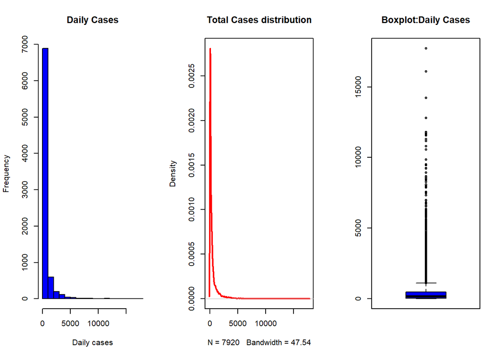

```r
par(mfrow=c(1,3))
hist(mydata_sorted$Daily_Cases, main = "Daily Cases",
     xlab = "Daily cases",
     ylab = "Frequency",
     col = "blue")
plot(density(mydata_sorted$Daily_Cases), main = "Total Cases distribution", col = "red",lwd = 2)
boxplot(mydata_sorted$Daily_Cases,col = "blue",main="Boxplot:Daily Cases")
```

```r
summary(mydata_sorted$Daily_Cases)
```

```
##    Min. 1st Qu.  Median    Mean 3rd Qu.    Max.
##     0.0    45.0   158.0   508.0   471.2 17716.0
```

The daily cases are skewed to the right as shown in the descriptive stats, histogram, density plot and boxplot. There appears to be outliers as shown by the boxplot but these values are extreme values which represent a time when COVID 19 cases were on the rise. The most daily cases observed in the data are between 0 and 1000.

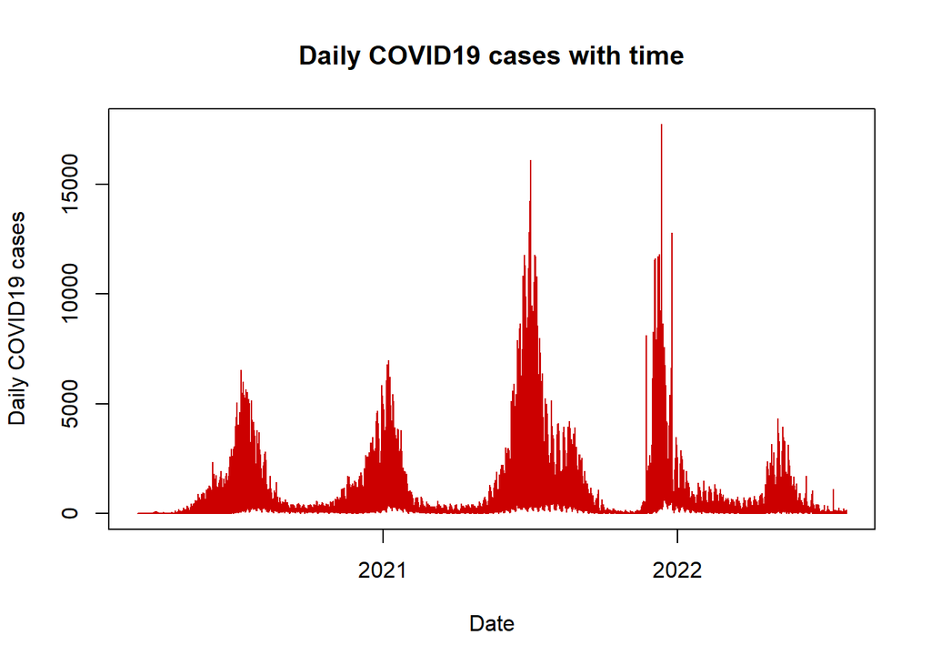

```r
plot(mydata_sorted$Date,mydata_sorted$Daily_Cases,type = "l",lwd = 1, col = "#cc0000",main = "Daily COVID19 cases with time",
     xlab = "Date",
     ylab = "Daily COVID19 cases")
```

### ii Daily Deaths

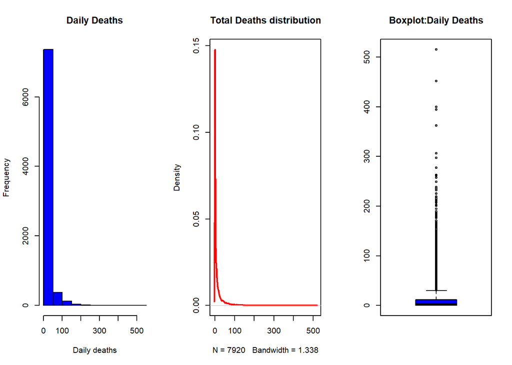

```r
par(mfrow=c(1,3))
mydata_sorted$Daily_Deaths = abs(mydata_sorted$Daily_Deaths)
mydata_sorted$Daily_Deaths = as.numeric(mydata_sorted$Daily_Deaths)
hist(mydata_sorted$Daily_Deaths, main = "Daily Deaths",
     xlab = "Daily deaths",
     ylab = "Frequency",
     col = "blue")
plot(density(mydata_sorted$Daily_Deaths), main = "Total Deaths distribution", col = "red",lwd = 2)
boxplot(mydata_sorted$Daily_Deaths,col = "blue",main="Boxplot:Daily Deaths")
```

The daily deaths are skewed to the right as shown in the descriptive stats, histogram, density plot and boxplot. There appears to be outliers as shown by the boxplot but these values are extreme values which represent a time when COVID 19 deaths were on the rise and this corresponds to the characteristics of the COVID19 Daily Cases. Most days recorded daily deaths between 0 and 50. The maximum number of deaths recorded a day is 515.

```r
summary(mydata_sorted$Daily_Deaths)
```

```
##    Min. 1st Qu.  Median    Mean 3rd Qu.    Max.
##    0.00    0.00    2.00   12.98   12.00  515.00
```

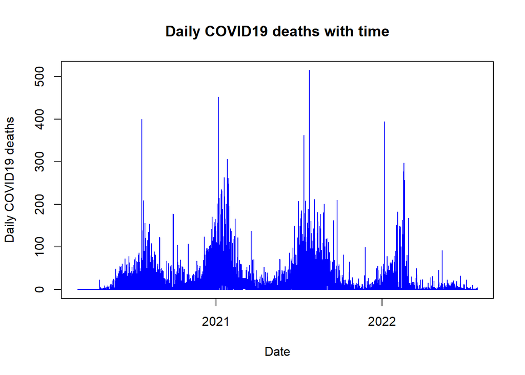

```r
plot(mydata_sorted$Date,mydata_sorted$Daily_Deaths,type = "l",lwd = 1, col = "blue",main = "Daily COVID19 deaths with time",
     xlab = "Date",
     ylab = "Daily COVID19 deaths")
```

### iii Total Recoveries

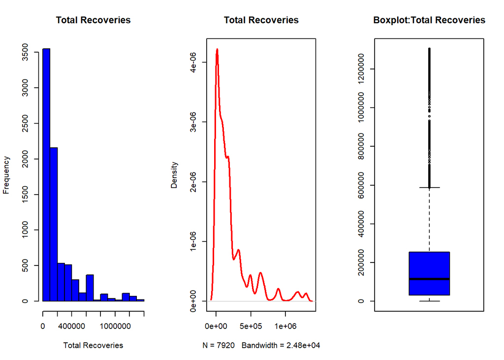

```r
par(mfrow=c(1,3))
hist(mydata_sorted$Total_Recoveries, main = "Total Recoveries",
     xlab = "Total Recoveries",
     ylab = "Frequency",
     col = "blue")
plot(density(mydata_sorted$Total_Recoveries),main = "Total Recoveries", col = "red",lwd = 2)
boxplot(mydata_sorted$Total_Recoveries,col = "blue",main="Boxplot:Total Recoveries")
```

### iv Total Cases

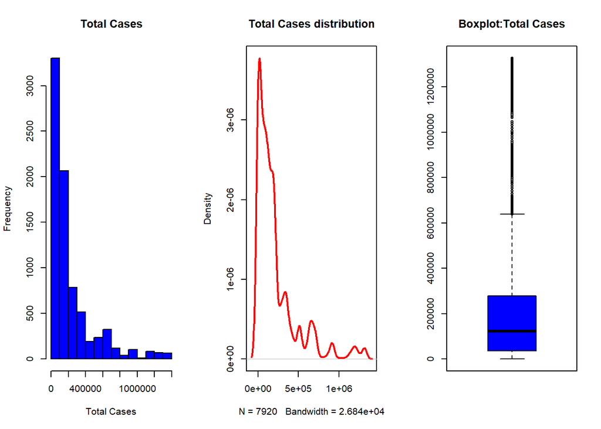

```r
par(mfrow=c(1,3))
hist(mydata_sorted$Total_Cases, main = "Total Cases",
     xlab = "Total Cases",
     ylab = "Frequency",
     col = "blue")
plot(density(mydata_sorted$Total_Cases), main = "Total Cases distribution", col = "red",lwd = 2)
boxplot(mydata_sorted$Total_Cases,col = "blue",main="Boxplot:Total Cases")
```

### v.Total Deaths

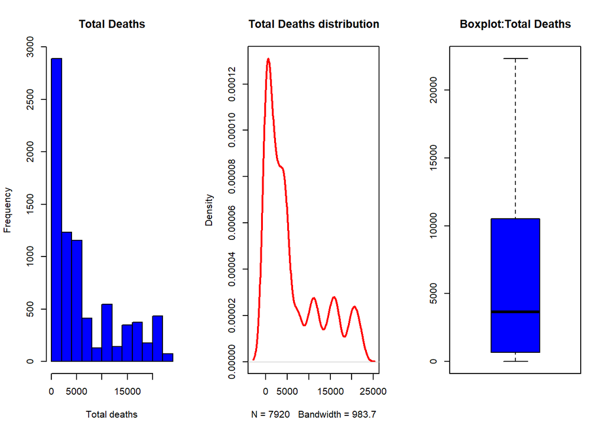

```r
par(mfrow=c(1,3))

hist(mydata_sorted$Total_Deaths, main = "Total Deaths",
     xlab = "Total deaths",
     ylab = "Frequency",
     col = "blue")
plot(density(mydata_sorted$Total_Deaths), main = "Total Deaths distribution", col = "red",lwd = 2)
boxplot(mydata_sorted$Total_Deaths,col = "blue",main="Boxplot:Total Deaths")
```

### vi.Cases 14 day average

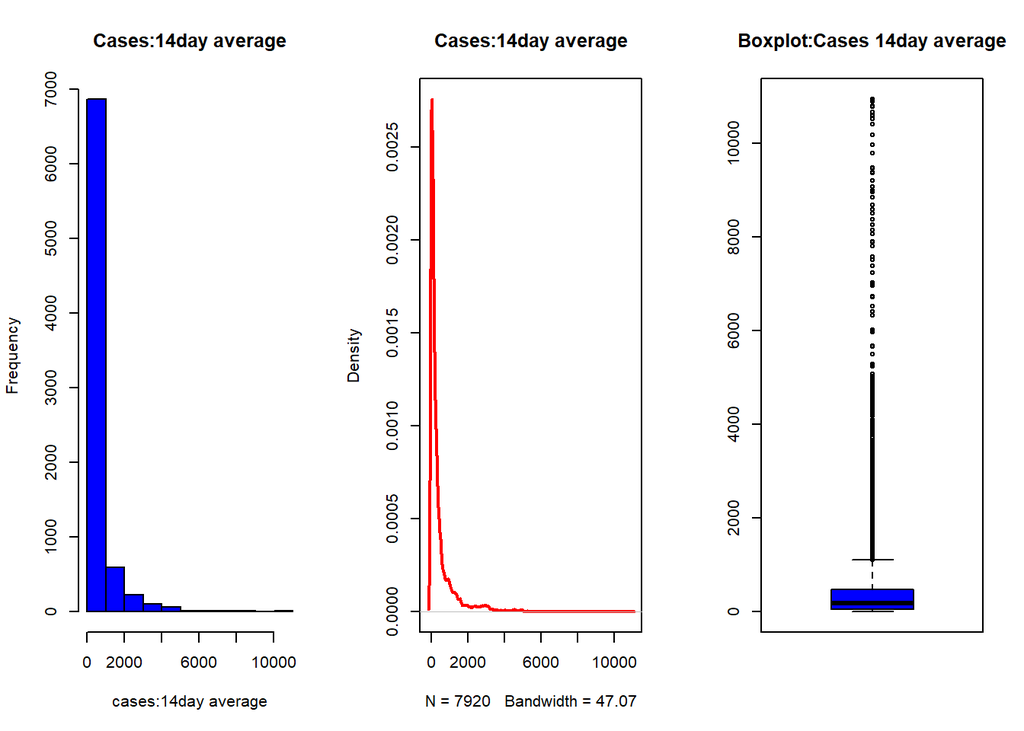

```r
par(mfrow=c(1,3))

hist(mydata_sorted$Cases_14day_average, main = "Cases:14day average",
     xlab = "cases:14day average",
     ylab = "Frequency",
     col = "blue")
plot(density(mydata_sorted$Cases_14day_average), main = "Cases:14day average", col = "red",lwd = 2)
boxplot(mydata_sorted$Cases_14day_average,col = "blue",main="Boxplot:Cases 14day average")
```

### vii.Deaths 14 day average

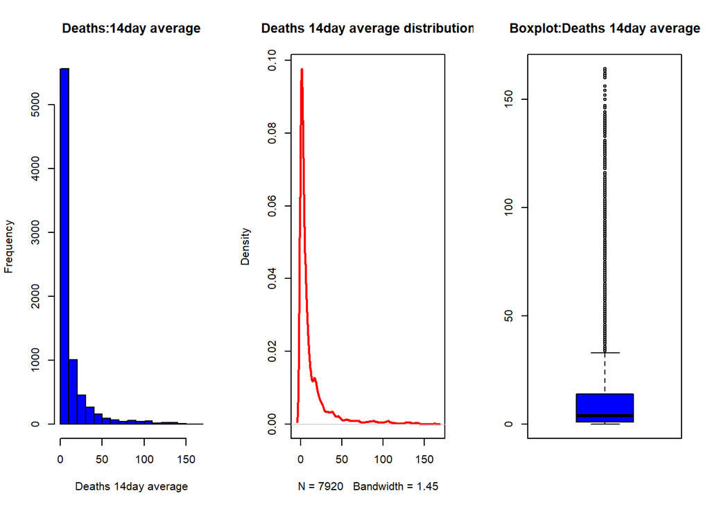

```r
par(mfrow=c(1,3))

hist(mydata_sorted$Deaths_14day_average, main = "Deaths:14day average",
     xlab = "Deaths 14day average",
     ylab = "Frequency",
     col = "blue")
plot(density(mydata_sorted$Deaths_14day_average), main = "Deaths 14day average distribution", col = "red",lwd = 2)
boxplot(mydata_sorted$Deaths_14day_average,col = "blue",main="Boxplot:Deaths 14day average")
```

## D.Multivariate Analysis

```r
by(mydata_sorted$Total_Cases,mydata_sorted$Province,summary)
```

```
## mydata_sorted$Province: Eastern Cape
##    Min. 1st Qu.  Median    Mean 3rd Qu.    Max.
##       0   90296  196573  201392  314094  364175
## ------------------------------------------------------------
## mydata_sorted$Province: Free State
##    Min. 1st Qu.  Median    Mean 3rd Qu.    Max.
##       0   49580   94448  107771  182860  216096
## ------------------------------------------------------------
## mydata_sorted$Province: Gauteng
##    Min. 1st Qu.  Median    Mean 3rd Qu.    Max.
##       0  221958  434208  618701 1111028 1325623
## ------------------------------------------------------------
## mydata_sorted$Province: KwaZulu-Natal
##    Min. 1st Qu.  Median    Mean 3rd Qu.    Max.
##       0  120016  337976  352181  581294  717147
## ------------------------------------------------------------
## mydata_sorted$Province: Limpopo
##    Min. 1st Qu.  Median    Mean 3rd Qu.    Max.
##       0   16028   64432   77342  137379  159682
## ------------------------------------------------------------
## mydata_sorted$Province: Mpumalanga
##    Min. 1st Qu.  Median    Mean 3rd Qu.    Max.
##       0   27894   79879   96492  171842  202248
## ------------------------------------------------------------
## mydata_sorted$Province: North West
##    Min. 1st Qu.  Median    Mean 3rd Qu.    Max.
##       0   30378   70901   95759  173923  202038
## ------------------------------------------------------------
## mydata_sorted$Province: Northern Cape
##    Min. 1st Qu.  Median    Mean 3rd Qu.    Max.
##       0   18343   44341   55168   98939  115306
## ------------------------------------------------------------
## mydata_sorted$Province: Western Cape
##    Min. 1st Qu.  Median    Mean 3rd Qu.    Max.
##       0  111966  289679  342136  565324  702220
```

```r
by(mydata_sorted$Total_Deaths,mydata_sorted$Province,summary)
```

```
## mydata_sorted$Province: Eastern Cape
##    Min. 1st Qu.  Median    Mean 3rd Qu.    Max.
##       0    3158   11615    9897   15284   16881
## ------------------------------------------------------------
## mydata_sorted$Province: Free State
##    Min. 1st Qu.  Median    Mean 3rd Qu.    Max.
##       0    1088    4017    4140    7139    7826
## ------------------------------------------------------------
## mydata_sorted$Province: Gauteng
##    Min. 1st Qu.  Median    Mean 3rd Qu.    Max.
##       0    4383   10870   11629   19934   21014
## ------------------------------------------------------------
## mydata_sorted$Province: KwaZulu-Natal
##    Min. 1st Qu.  Median    Mean 3rd Qu.    Max.
##       0    2899   10456    9133   14858   16246
## ------------------------------------------------------------
## mydata_sorted$Province: Limpopo
##    Min. 1st Qu.  Median    Mean 3rd Qu.    Max.
##     0.0   419.5  2336.0  2342.5  4120.0  4675.0
## ------------------------------------------------------------
## mydata_sorted$Province: Mpumalanga
##    Min. 1st Qu.  Median    Mean 3rd Qu.    Max.
##       0     580    1418    1743    2021    4764
## ------------------------------------------------------------
## mydata_sorted$Province: North West
##    Min. 1st Qu.  Median    Mean 3rd Qu.    Max.
##       0     375    1798    2300    4404    5019
## ------------------------------------------------------------
## mydata_sorted$Province: Northern Cape
##    Min. 1st Qu.  Median    Mean 3rd Qu.    Max.
##     0.0   228.0   978.5  1375.5  2443.2  3249.0
## ------------------------------------------------------------
## mydata_sorted$Province: Western Cape
##    Min. 1st Qu.  Median    Mean 3rd Qu.    Max.
##       0    4237   11708   12219   20296   22308
```

Though Gauteng has had the highest number of total COVID19 cases, more people have died due to COVID19 related complications in Western Cape.

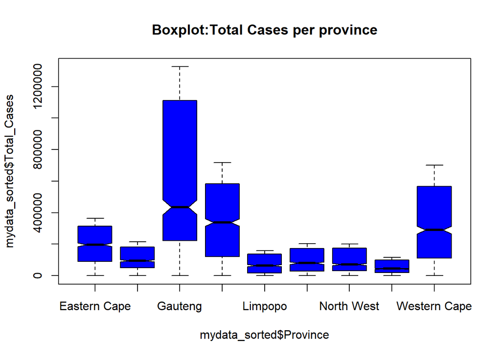

```r
boxplot(mydata_sorted$Total_Cases~mydata_sorted$Province,notch = T,col="blue",main =
          "Boxplot:Total Cases per province")
```

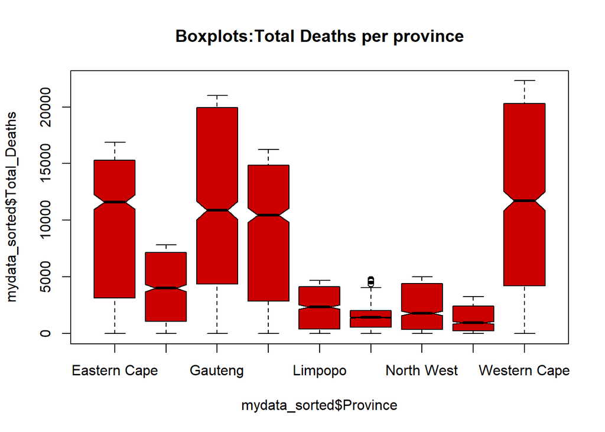

```r
boxplot(mydata_sorted$Total_Deaths~mydata_sorted$Province,notch = T,col="#cc0000", main =
          "Boxplots:Total Deaths per province")
```

The boxplots above give a relative comparison of the total cases and total deaths for all the provinces.

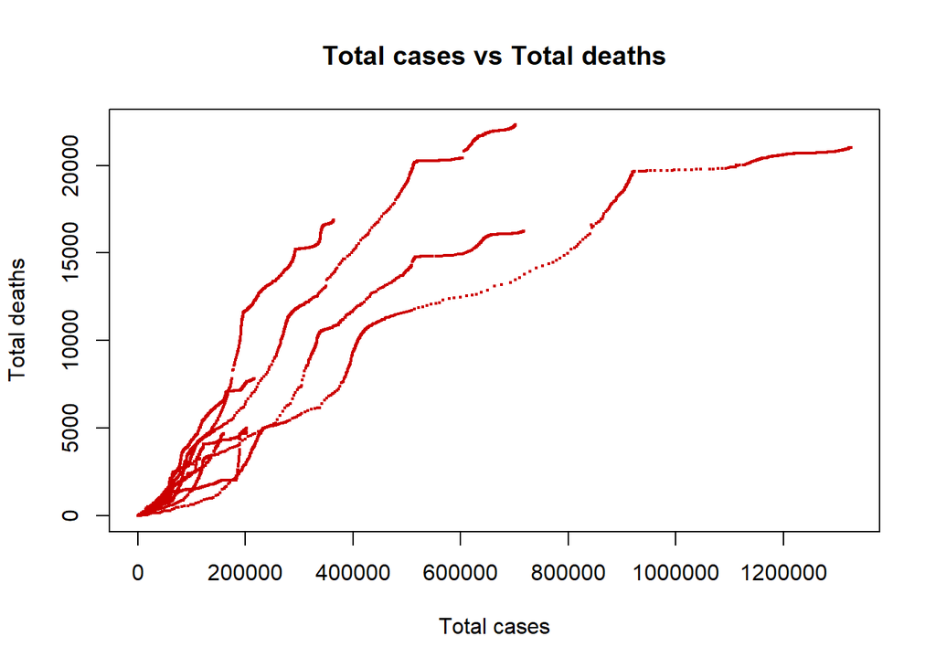

```r
plot(mydata_sorted$Total_Cases,mydata_sorted$Total_Deaths,
     pch = 19,
     cex = 0.3,
     col = "#cc0000",
     main = "Total cases vs Total deaths",
     xlab = "Total cases",
     ylab = "Total deaths")
```

### Scatter plots: Total cases vs Total deaths per province

#### 1.Gauteng

```r
gauteng = subset(mydata_sorted,Province == "Gauteng")
```

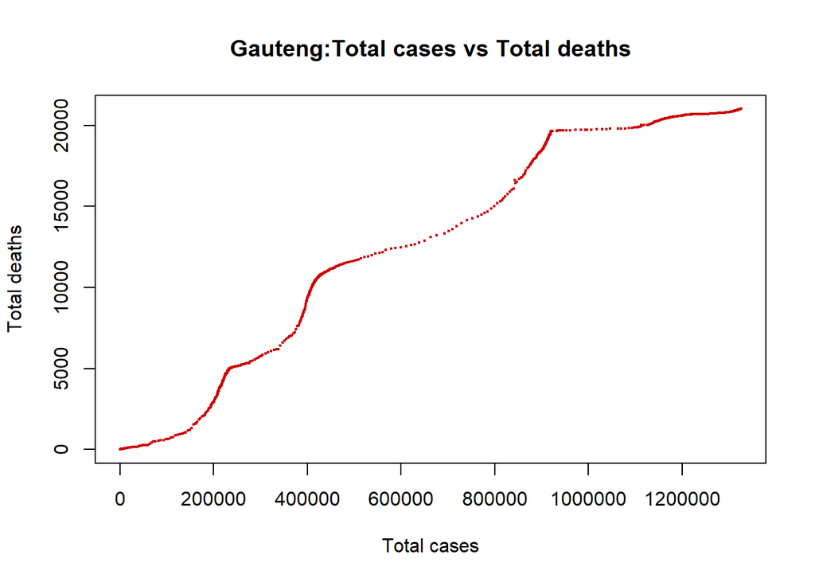

```r
plot(gauteng$Total_Cases,gauteng$Total_Deaths,
     pch = 19,
     cex = 0.3,
     col = "#cc0000",
     main = "Gauteng:Total cases vs Total deaths",
     xlab = "Total cases",
     ylab = "Total deaths")
```

#### Eastern Cape

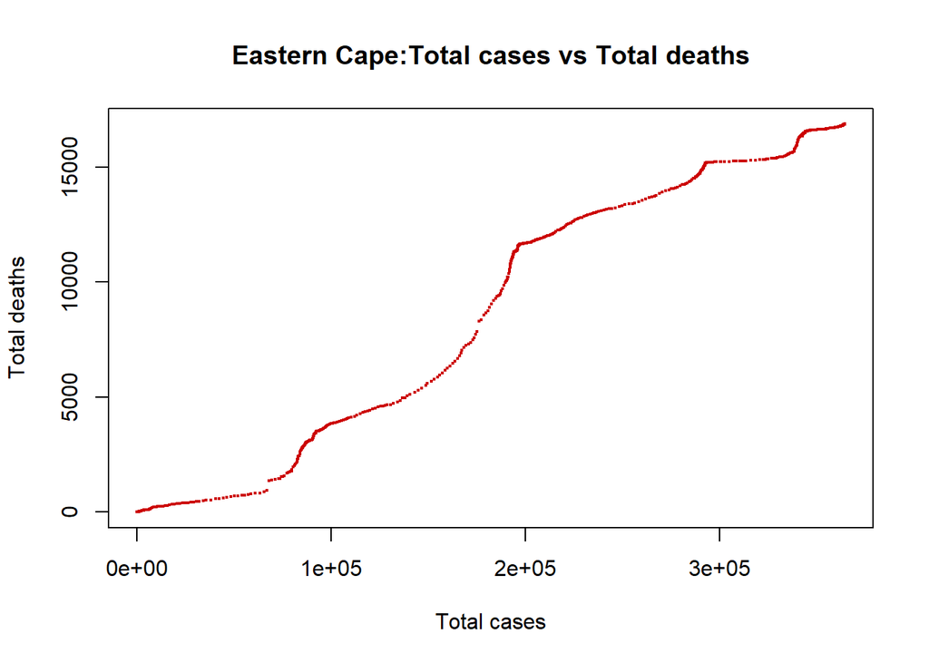

```r
EC = subset(mydata_sorted,Province == "Eastern Cape")
plot(EC$Total_Cases,EC$Total_Deaths,
     pch = 19,
     cex = 0.3,
     col = "#cc0000",
     main = "Eastern Cape:Total cases vs Total deaths",
     xlab = "Total cases",
     ylab = "Total deaths")
```

#### Free State

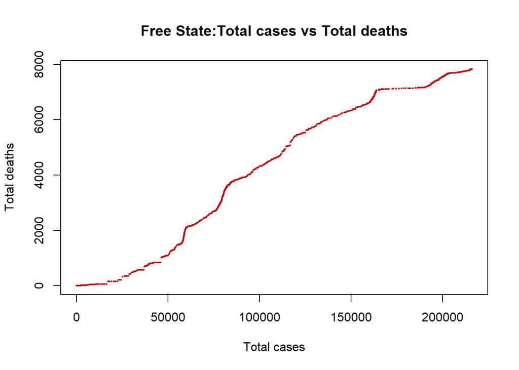

```r
FS = subset(mydata_sorted,Province == "Free State")
plot(FS$Total_Cases,FS$Total_Deaths,
     pch = 19,
     cex = 0.3,
     col = "#cc0000",
     main = "Free State:Total cases vs Total deaths",
     xlab = "Total cases",
     ylab = "Total deaths")
```

#### KwaZulu-Natal

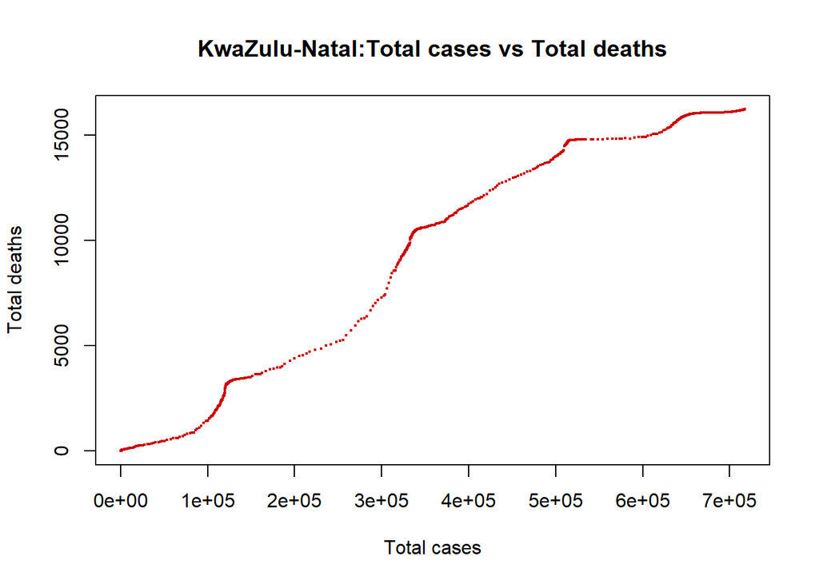

```r
kzn = subset(mydata_sorted,Province == "KwaZulu-Natal")
plot(kzn$Total_Cases,kzn$Total_Deaths,
     pch = 19,
     cex = 0.3,
     col = "#cc0000",
     main = "KwaZulu-Natal:Total cases vs Total deaths",
     xlab = "Total cases",
     ylab = "Total deaths")
```

#### Mpumalanga

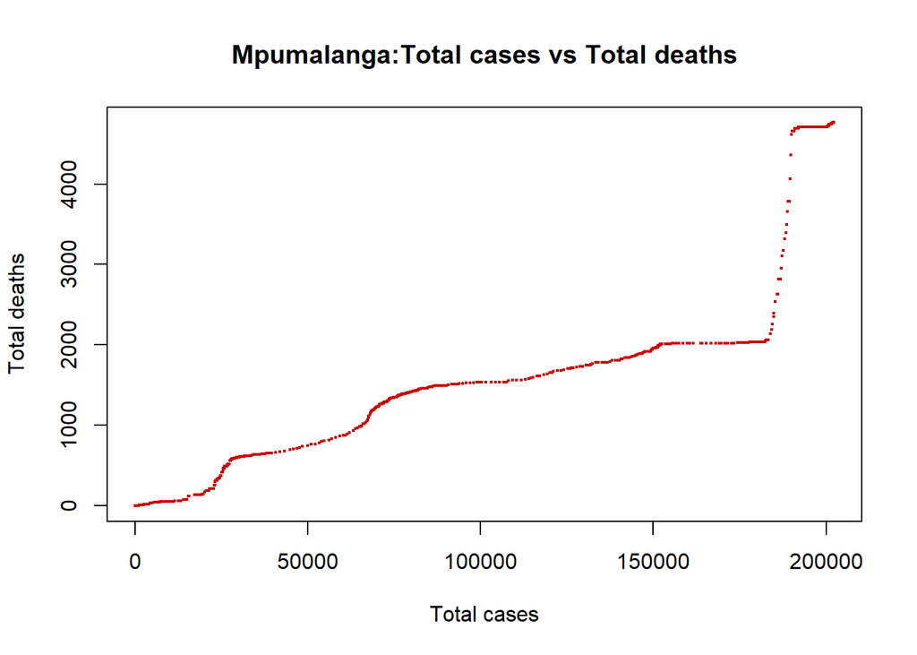

```r
MP = subset(mydata_sorted,Province == "Mpumalanga")
plot(MP$Total_Cases,MP$Total_Deaths,
     pch = 19,
     cex = 0.3,
     col = "#cc0000",
     main = "Mpumalanga:Total cases vs Total deaths",
     xlab = "Total cases",
     ylab = "Total deaths")
```

#### Limpopo

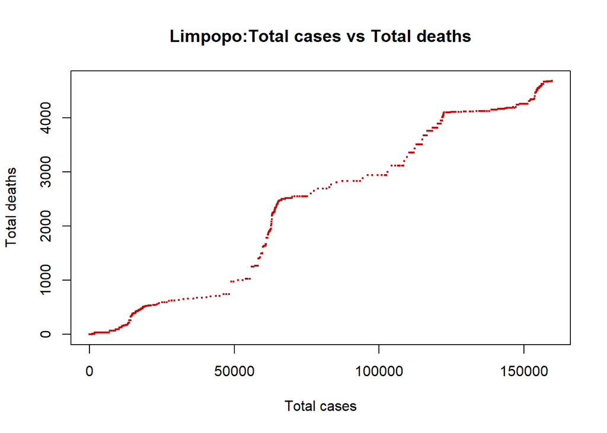

```r
LP = subset(mydata_sorted,Province == "Limpopo")
plot(LP$Total_Cases,LP$Total_Deaths,
     pch = 19,
     cex = 0.3,
     col = "#cc0000",
     main = "Limpopo:Total cases vs Total deaths",
     xlab = "Total cases",
     ylab = "Total deaths")
```

Death rate = 0.0294

#### North West

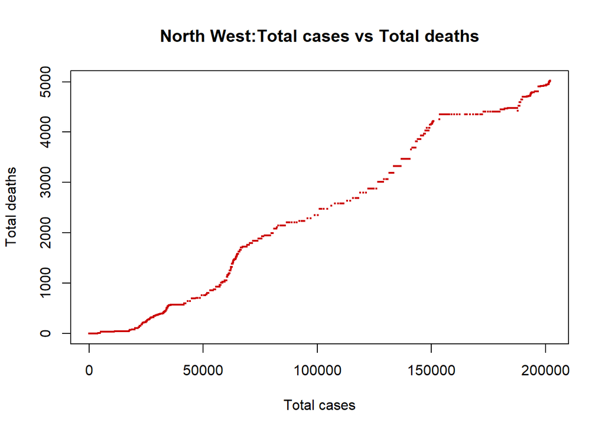

```r
NW = subset(mydata_sorted,Province == "North West")
plot(NW$Total_Cases,NW$Total_Deaths,
     pch = 19,
     cex = 0.3,
     col = "#cc0000",
     main = "North West:Total cases vs Total deaths",
     xlab = "Total cases",
     ylab = "Total deaths")
```

Death rate = 0.024

#### Northern Cape

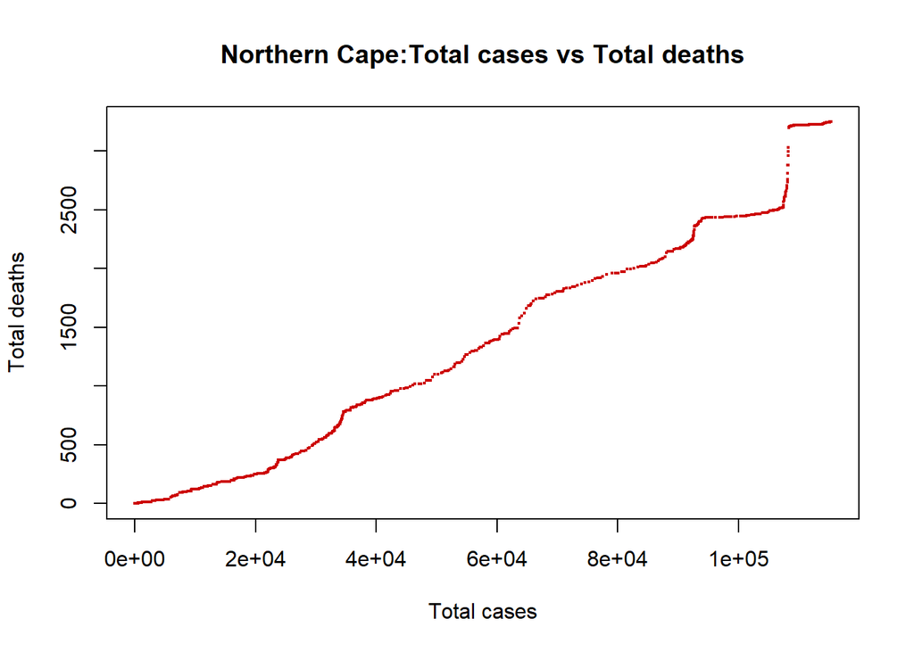

```r
NC = subset(mydata_sorted,Province == "Northern Cape")
plot(NC$Total_Cases,NC$Total_Deaths,
     pch = 19,
     cex = 0.3,
     col = "#cc0000",
     main = "Northern Cape:Total cases vs Total deaths",
     xlab = "Total cases",
     ylab = "Total deaths")
```

#### Western Cape

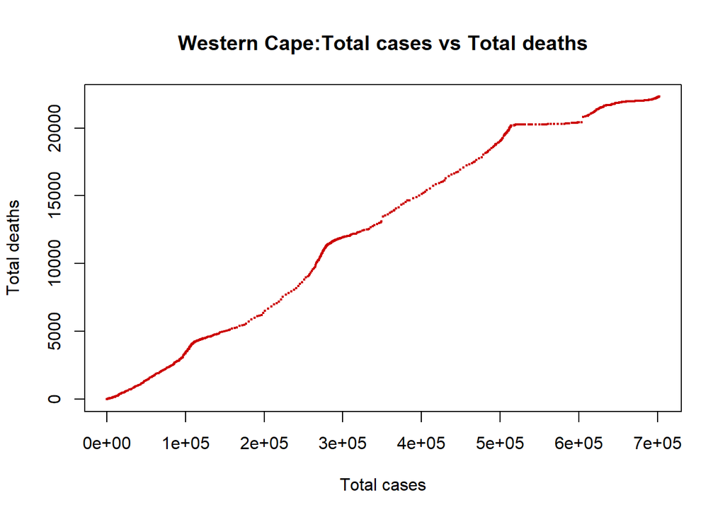

```r
WC = subset(mydata_sorted,Province == "Western Cape")
plot(WC$Total_Cases,WC$Total_Deaths,
     pch = 19,
     cex = 0.3,
     col = "#cc0000",
     main = "Western Cape:Total cases vs Total deaths",
     xlab = "Total cases",
     ylab = "Total deaths")
```

# 4.Data Visualization using Tableau

To view the dashboard on Tableau Public use the link below:

https://public.tableau.com/app/profile/mufaro.chinake/viz/SouthAfricaCOVID19Analysis/Dashboard1